# Porównywanie wykresów kołowych i słupkowych - eksperyment

Hryn Zofia

2023-03-27

## Opis eksperymentu

Celem mojego doświadczenie było zbadanie, czy użytkownicy lepiej odczytują i porównują dane z wykresu słupkowego, czy z kołowego. Eksperyment składał się z dwóch podobnych do siebie części. W pierwszej z nich ankietowany był proszony o stwierdzenie czy odczytywanie wartości z wykresu kołowego jest łatwe, a następnie uszeregowanie napojów, pod względem ilości kofeiny w nich zawartej. Dokładnie te same polecenia znajdowały się w części drugiej, jednak tym razem dotyczyły wykresu słupkowego. Dodatkowo odpowiadający mieli możliwośc napisania komentarza dotyczącego eksperymentu, którym przyjrzymy się pod koniec raportu. Badanie zostało przeprowadzone przy pomocy formularza Microsoft Forms i jest dostępne pod adresem: https://forms.office.com/e/bRA6CmZyn6 .

# Wykresy i pytania

Poniżej zamieszczono użyte w badaniu pytania i wykresy:

1. Czy miałeś wcześniej do czynienia z technikami wizualizacji danych / eksploracją danych?
2. Czy uważasz, że z wykresu kołowego można łatwo odczytywać dane?
3. Uszereguj w kolejności napoje, w taki sposób by jedynkę (1) otrzymał ten który ma najmniejszą zawartość kofeiny. Pamiętaj, jeżeli uważasz, że dane mają taką samą ilość kofeiny, przyporządkuj im taki sam numer.

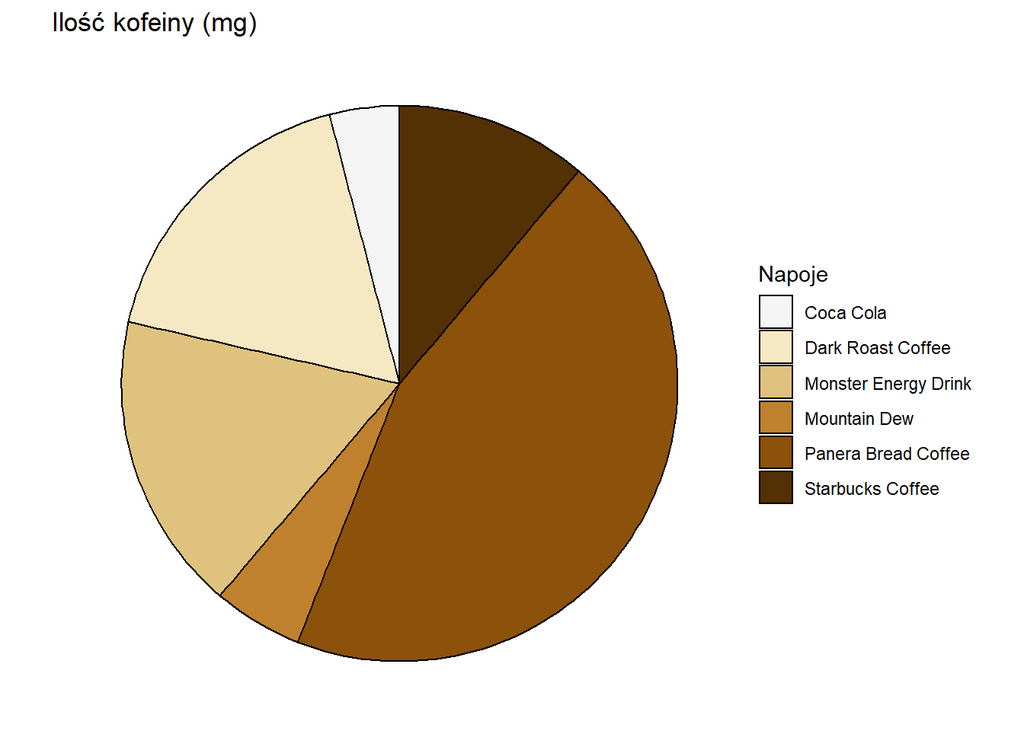

4. Czy uważasz, że z wykresu słupkowego można łatwo odczytywać dane?
5. Uszereguj w kolejności napoje, w taki sposób by jedynkę (1) otrzymał ten który ma najmniejszą zawartość kofeiny. Pamiętaj, jeżeli uważasz, że dane mają taką samą ilość kofeiny, przyporządkuj im taki sam numer.

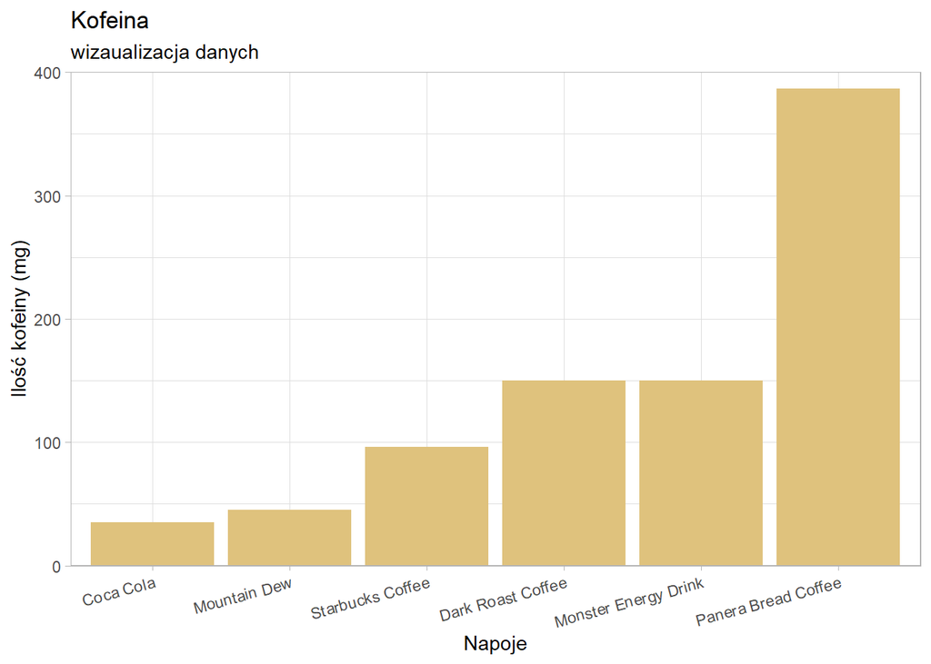

6. Miejsce na uwagi dotyczące odczytywania danych z wykresów kołowych i słupkowych.

## Wyniki

Grupa badawcza wyniosła 20 osób. W większości byli to studenci wieku 18-21 lat, ale w badaniu wzięło również kilka osób w wieku pracującym. Ze względu na anonimowość ankiety, nie można stwierdzić dokładnych statystyk.

Czternastu ankietowanych odpowiedziało, że miało wcześniej kontakt z technikami wizualizacji danych lub/i eksploracją danych. Ten wynik był dla mnie zaskakujący, gdyż w ankiecie nie brały udziału osoby z naszego wydziału, więc nie spodziewałam się, że aż 70% odpowiadających miało styczność z tymi zagadnieniami.

Niemal wszyscy stwierdzili, że łatwo odczytuje się dane z wykresów kołowych, co zostało zweryfikowane w zadaniu 3. Niestety okazuje się, że pomimo wcześniejszej deklaracji, duża część osób miałą problem z poprawnych zinterpretowaniem i porównaniem wyników. Poprawne odpowiedzi były następujące:

1. Coca Cola - 35 mg
2. Mountain Dew - 45 mg
3. Starbucks Coffee - 96 mg
4. Dark Roast Coffee, Monster Energy Drink - 150 mg każdy
5. / 6. Panera Bread Coffee - 387 mg

Tutaj tabela z wynikami otrzymanymi w zadaniu 3:

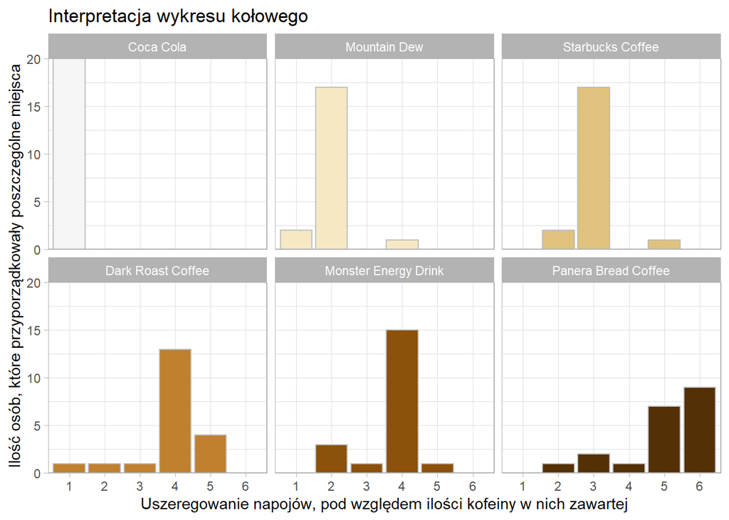

Analizując dane możemy zobaczyć, że z każdym kolejnym napojem, ankietowani mieli większe problemy. Nikt nie miał wątpliwości, że w Coca Coli jest najmniej kofeiny, jednak niektórzy umiejscawiali ją na tym samym miejscu co Mountain Dew, czy Dark Roast Coffee, w których kofeiny jest znacznie więcej. Niestety taki błąd przesuwał wszystkie kolejne przyporządkowania. Porównując otrzymane wyniki możemy zauważyć, że kolejność pierwszych trzech napojów jest mimo wszystko w miarę zachowana. Największe niejasności pojawiają się przy Dark Roast Coffee i Monster Energy Drink. Nie każdy potrafił jednoznacznie stwierdzić, który z tych napojów ma większą zawartość kofeiny. Wysokości słupków dla Panera Bread Coffee są zaburzone przez sposób sformułowania ankiety. Nie chcąc by uczestnicy sugerowali się ilością przyporządkowań, przygotowane zostały numery od 1 do 6. Mimo tego, że znaczna większość wskazała, że Panera jest ostatnia, dane są najbardziej rozproszone.

Kolejne pytanie dotyczyło łatwości analizy i porównywania danych na wykresach słupkowych. Wszyscy jednogłośnie odpowiedzieli, że taka wizualizacja jest prosta do odczytu. Poniżej na diagramach możemy zobaczyć jak rozkładały się odpowiedzi:

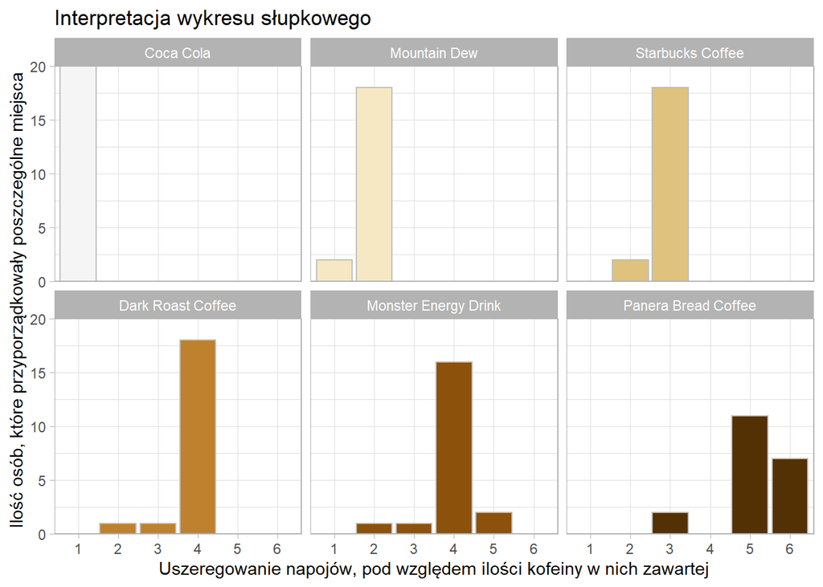

Widzimy, że jakość interpretacji i porównywania danych się poprawiła. Wyniki są mniej rozproszone i jeszcze bardziej skoncentrowane przy poprawnych wartościach. Analizując poszczególne wyniki, dochodzę do wniosku, że uczestnicy mieli znacznie mniejszy problem z poprawnym uszeregowaniem wartości.

Ostatnie pytanie miało na celu poznanie opinii uczestników, na temat eksperymentu i wizualizacji danych przy pomocy obu wykresów. Przytoczę dwie z nich.

“Małe różnice bardziej widać na wykresach słupkowych. Kołowe lepsze byłyby do procentowego pokazania czegoś, bardziej niż porównywania.”

“Dane z wykresów słupkowych są łatwiejsze do odczytu. Niewielkie różnice w wartościach są łatwiejsze do zauważenia.”

## Podsumowanie

Analizując rezultaty eksperymentu dochodzę do wniosku, że łatwiej jest interpretować wykresy słupkowe niż kołowe. Nie zwracając uwagi na samą niepoprawność przestawiania tych konkretnych danych w postaci wykresu kołowego (dane nie sumowały się do 100 procent), zauważam, że wyniki dla tych wizualizacji były bardziej rozproszone. W moim modelu było tylko sześć kategorii, ale zakładam, że przy większej liczbie danych i ich większym wyrównaniu, róznice na tym wykresie byłyby wręcz niezauważalne. Zdecydowanie bardziej czytelne są wykresy słupkowe.